# elhwa-river-ndvi

### Lower Elwha Klallum Tribe - Elwha River Dam Removal - Vegetation Changes NDVI Analysis using Python

##### Introduction

From the 1930s to the 1970s the United States experienced a dramatic increase in dam building, sometimes referred to as “The Big Dam Era” (Lee, 2023), for benefits such as hydropower, flood control, irrigation, and water supply. However, later in the 20th century research began to show that dams often had unforeseen consequences such as habitat loss, habitat fragmentation, species impacts such as salmon, sediment transport reduction, and social impacts like displaced communities or livelihoods. In more recent decades, with the growing evidence, dam removal is becoming more frequent in an attempt to restore the habitat, natural hydrologic flow, and sediment transport. The dams are also aging infrastructure.

A major dam removal project in WA was along the Elwha River. One of the biggest concerns for the Lower Elwha Klallum Tribe (LEKT) was the impact on salmon migration and fish passage. The Elwha River was once a thriving salmon habitat with plentiful fish, but dams can alter fish migration due to changes in sediment load, hydrologic flow, and water quality changes such as temperature, nutrients, and oxygen (U.S. Environmental Protection Agency, 2021). Salmon had been a major part of the lives of the Lower Elwha Klallum people for cultural, spiritual and physical purposes (Guarino, 2013). The LEKT played a major role in advocating for the removal of the Elwha River through lobbying Congress.

##### Location

The Elwha River is 45 miles originating in the Olympic Mountains running to the Strait of Juan De Fuca. There were two dams that were removed along the Elwha River, the Elwha Dam removal completed in 2012 and Glines Canyon Dam which was fully removed in 2014. This dam removal project was a huge undertaking and it was the largest in history at the time. It reopened 75 miles of salmon habitat (U.S. NOAA Fisheries, 2025).

##### Methods

To evaluate long-term vegetation change in the Lower Elwha Klallam Tribe (LEKT) boundary areas, this analysis used MODIS MOD13Q1 16-day NDVI data and a polygon from OpenStreetMap (OSM) to define the study boundary. First, a site map was created, and the LEKT boundary was found through OPM. Then, the NDVI raster data for the region was downloaded through NASA Earth Data. The data was then cleaned and processed for further analysis.

To explore changes over time, the NDVI temporal mean was calculated for two periods: 2008–2011 and 2012–2018, representing conditions before and after the dam removals in 2012 and 2014. The early-period mean was subtracted from the later-period mean to create a raster showing the long-term difference in vegetation health.

```python
# Import libraries for storing and filing data
import os
import pathlib

# Import for finding map
from osmnx import features as osm
import osmnx as ox

# Import libraries for working with raster data
import hvplot.xarray
import rioxarray as rxr
import xarray as xr

# Import library for working with dataframes
import pandas as pd

# Import library for working with geodataframes, vector data
import geopandas as gpd

# Import library for plotting
import matplotlib.pyplot as plt

# Import library for making interactive maps and plots
import holoviews as hv
import hvplot.pandas

# Import for downloading data
import earthpy
import earthpy.api.appeears as eaapp

# Import library combine data arrays
import glob
```

```python
### Define project
project = earthpy.Project("Lower Elwha River Klallam Vegetation Change", dirname = 'lower_elwha')
```

```python
# Search for Lower Elwha River Klallam Tribal Land
lower_elwha_gdf = ox.geocode_to_gdf('Lower Elwha Klallam Tribe')

# Call the geodataframe
lower_elwha_gdf
```

|  | geometry | bbox_west | bbox_south | bbox_east | bbox_north | place_id | osm_type | osm_id | lat | lon | class | type | place_rank | importance | addresstype | name | display_name |
| --- | --- | --- | --- | --- | --- | --- | --- | --- | --- | --- | --- | --- | --- | --- | --- | --- | --- |
| 0 | MULTIPOLYGON (((-123.60319 48.12836, -123.5979... | -123.603192 | 48.100534 | -123.530591 | 48.151398 | 350356005 | relation | 5762804 | 48.137795 | -123.550112 | boundary | aboriginal_lands | 25 | 0.066702 | aboriginal_lands | Lower Elwha Klallam Tribe | Lower Elwha Klallam Tribe, Clallam County, Was... |

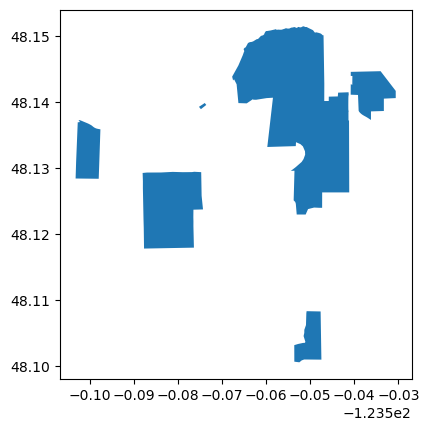

```python
# Plot the polygon to check shape
lower_elwha_gdf.plot()
```

```python
# Plot the results with web tile images
lower_elwha_gdf.hvplot(
    geo=True, tiles='EsriImagery',
    fill_color=None, line_color='black',
    title='Lower Elwha Klallam Tribe',
    frame_width=500)
```

[output not shown]

```python
### Initialize AppeearsDownloader for MODIS NDVI data
### Set parameters
ndvi_downloader = eaapp.AppeearsDownloader(

    ### Name download
    download_key = "lower_elwha_ndvi",

    ### Put data in project (already defined)
    project = project,

    ### Specify the MODIS product
    product = 'MOD13Q1.061',
    layer = '_250m_16_days_NDVI',

    ### Choose a start date and end date
    start_date = "06-01",
    end_date = "09-01",

    ### Recurring means you want those dates over multiple years
    recurring = True,

    ### Specify the range of years you want
    year_range = [2008, 2018],

    ### Specify the polygon you want to get NDVI data for
    polygon = lower_elwha_gdf
)
```

In the future for a larger dataset, I would submit request using ndvi_downloader.submit() instead and let NASA process the request first... then come back once the dataset has been downloaded.

```python
# Download data
ndvi_downloader.download_files(cache=True)
```

```
<generator object Path.rglob at 0x7916436ffcd0>
```

```python
# Get a sorted list of NDVI tif file paths
elwha_ndvi_paths = sorted(
    list(
        project.project_dir.rglob(
            'MOD13Q1.061_2008138_to_2018244/MOD13Q1.061__250m_16_days_NDVI_doy*.tif'
        )
    )
)

# Display the first and last three files paths to check the pattern
elwha_ndvi_paths[:3], elwha_ndvi_paths[-3:]
```

```
([PosixPath('/workspaces/data/lower_elwha/lower_elwha_ndvi/MOD13Q1.061_2008138_to_2018244/MOD13Q1.061__250m_16_days_NDVI_doy2008145000000_aid0001.tif'),
  PosixPath('/workspaces/data/lower_elwha/lower_elwha_ndvi/MOD13Q1.061_2008138_to_2018244/MOD13Q1.061__250m_16_days_NDVI_doy2008161000000_aid0001.tif'),
  PosixPath('/workspaces/data/lower_elwha/lower_elwha_ndvi/MOD13Q1.061_2008138_to_2018244/MOD13Q1.061__250m_16_days_NDVI_doy2008177000000_aid0001.tif')],
 [PosixPath('/workspaces/data/lower_elwha/lower_elwha_ndvi/MOD13Q1.061_2008138_to_2018244/MOD13Q1.061__250m_16_days_NDVI_doy2018209000000_aid0001.tif'),
  PosixPath('/workspaces/data/lower_elwha/lower_elwha_ndvi/MOD13Q1.061_2008138_to_2018244/MOD13Q1.061__250m_16_days_NDVI_doy2018225000000_aid0001.tif'),
  PosixPath('/workspaces/data/lower_elwha/lower_elwha_ndvi/MOD13Q1.061_2008138_to_2018244/MOD13Q1.061__250m_16_days_NDVI_doy2018241000000_aid0001.tif')])
```

```python
# Calculate the charector number from file path
doy_start = -25
doy_end = -19

# Create empty list
elwha_ndvi_das = []

# Loop through each NDVI image
for elwha_ndvi_path in elwha_ndvi_paths:

    # Get date from file name
    doy = elwha_ndvi_path.name[doy_start:doy_end]
    date = pd.to_datetime(doy, format='%Y%j')

    # Open and read dataset and .tif file
    da = rxr.open_rasterio(elwha_ndvi_path, mask_and_scale=True).squeeze()

    # Add date dimension and clean up metadata, da is image
    da = da.assign_coords({'date': date}) # Assign coordinates
    da = da.expand_dims({'date': 1}) # Remove stray values
    da.name = 'NDVI' # Name data array

    # Prepare for concatenation
    elwha_ndvi_das.append(da)

# Return length of new list
len(elwha_ndvi_das)
```

```
77
```

```python
# Combine NDVI images from all dates using xarray
elwha_ndvi_da = xr.combine_by_coords(elwha_ndvi_das, coords=['date'])

# Call the dataarray
elwha_ndvi_da
```

```
<xarray.Dataset> Size: 278kB
Dimensions:      (date: 77, y: 25, x: 36)
Coordinates:
    band         int64 8B 1
  * x            (x) float64 288B -123.6 -123.6 -123.6 ... -123.5 -123.5 -123.5
  * y            (y) float64 200B 48.15 48.15 48.15 48.14 ... 48.11 48.1 48.1
    spatial_ref  int64 8B 0
  * date         (date) datetime64[ns] 616B 2008-01-14 2008-01-16 ... 2018-01-24
Data variables:
    NDVI         (date, y, x) float32 277kB nan nan nan ... 0.5306 0.5955 0.6321
```

```python
# Call ndvi_paths to look at data
elwha_ndvi_paths
```

[output not shown]

[output cut: 51 more lines]

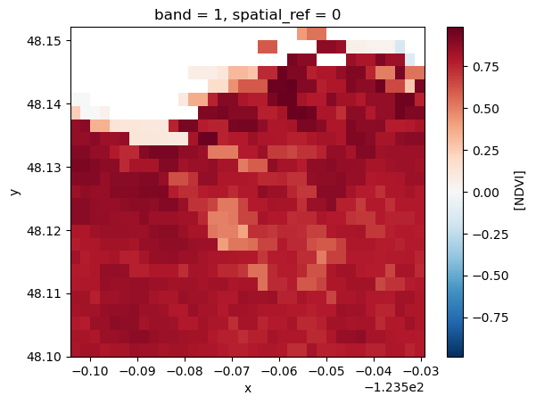

```python
# Plot the first tif image file
rxr.open_rasterio(elwha_ndvi_paths[0], mask_and_scale=True).squeeze().plot()
```

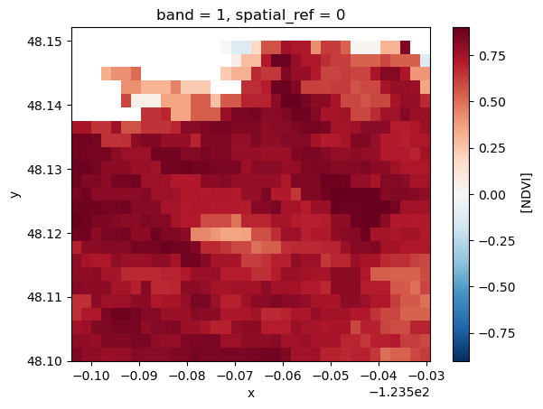

```python
# Plot the last tif image file
rxr.open_rasterio(elwha_ndvi_paths[-1], mask_and_scale=True).squeeze().plot()
```

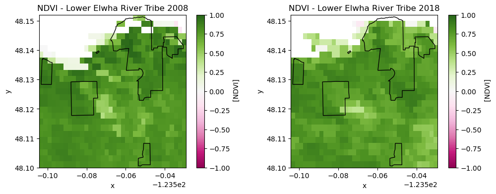

```python
# Create variables for each raster to create side-by-side for comparison
recent_ndvi = rxr.open_rasterio(elwha_ndvi_paths[-1], mask_and_scale=True).squeeze()
old_ndvi = rxr.open_rasterio(elwha_ndvi_paths[0], mask_and_scale=True).squeeze()

# Create and plot side-by-side subplots
fig, axes = plt.subplots(1, 2, figsize=(12, 4))

# Plot first 2001 image on left
old_ndvi.plot(ax=axes[0], cmap=plt.cm.PiYG, vmin=-1, vmax=1)
# Add boundary from AITSN geodataframe
lower_elwha_gdf.plot(ax=axes[0],
                  edgecolor='black',
                  facecolor='none', # No fill
                  linewidth=1
)
# Add title
axes[0].set_title("NDVI - Lower Elwha River Tribe 2008")

# Plot most recent 2022 image on right
recent_ndvi.plot(ax=axes[1], cmap=plt.cm.PiYG, vmin=-1, vmax=1)

# Add boundary from AITSN geodataframe
lower_elwha_gdf.plot(ax=axes[1],
                  edgecolor='black',
                  facecolor='none',
                  linewidth=1
)

# Add title
axes[1].set_title("NDVI - Lower Elwha River Tribe 2018")
```

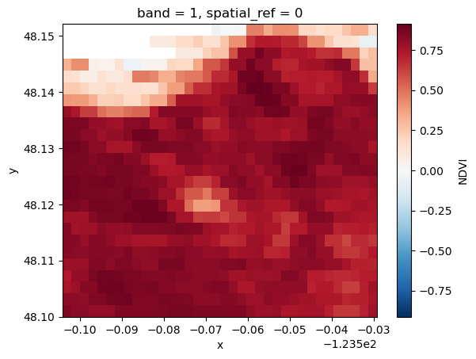

```python
# Calculate the mean of 2001 to 2011 NDVI data
mean_ndvi_2008_2011 = elwha_ndvi_da.sel(date=slice('2008', '2011')).mean('date').NDVI

# Plot the mean to check and view the data
mean_ndvi_2008_2011.plot()
```

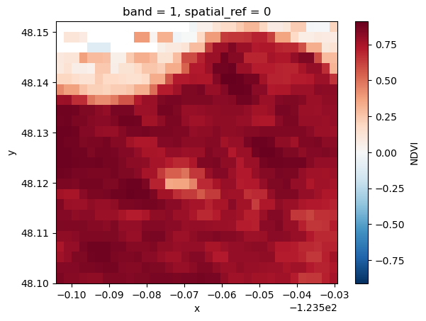

```python
# Calculate the mean of 2012 to 2022 NDVI data
mean_ndvi_2012_2018 = elwha_ndvi_da.sel(date=slice('2012', '2018')).mean('date').NDVI

# Plot the mean to check and view the data
mean_ndvi_2012_2018.plot()
```

```python
# Compute the difference in NDVI before and after the return of water rights
ndvi_diff =(
    elwha_ndvi_da
        .sel(date=slice('2012', '2018')) # Date range
            .mean('date') # Calculate mean of date
            .NDVI # Use NDVI data
    - elwha_ndvi_da
        .sel(date=slice('2008', '2011'))
            .mean('date')
            .NDVI
)

# Call the NDVI data
ndvi_diff
```

```
<xarray.DataArray 'NDVI' (y: 25, x: 36)> Size: 4kB
array([[            nan,             nan,             nan,
                    nan,             nan,             nan,
                    nan,             nan,             nan,
                    nan,             nan,             nan,
                    nan,             nan,             nan,
                    nan,             nan,  1.59833301e-02,
         5.60999960e-02,  5.60999960e-02,  1.11924991e-01,
        -2.90786684e-01, -2.90786684e-01, -1.02350011e-01,
        -1.17858678e-01, -1.17858678e-01, -2.21497431e-01,
        -1.18631475e-01, -1.18631475e-01, -3.64562497e-02,
         4.85071540e-02,  4.85071540e-02, -2.72341073e-01,
        -3.45161915e-01, -3.45161915e-01,  3.60066593e-02],
       [            nan,             nan,             nan,
                    nan,             nan,             nan,
                    nan,             nan,             nan,
                    nan,  2.98099995e-01,  2.98099995e-01,
        -7.19999969e-02,  1.52638078e-01,  1.52638078e-01,
        -2.51341641e-01, -1.50311545e-01, -1.50311545e-01,
        -7.40708709e-02, -2.82155871e-02, -2.82155871e-02,
        -2.85843611e-02, -7.72041082e-02, -7.72041082e-02,
...
        -7.21907616e-03, -7.21907616e-03, -3.17695737e-02,
        -2.04396248e-02, -2.04396248e-02, -6.85912371e-03,
         8.62073898e-03,  8.62073898e-03, -1.09332800e-03,
        -1.27083063e-03, -1.27083063e-03, -4.71222401e-03,
        -1.42127872e-02, -1.42127872e-02, -1.85966492e-03,
         1.30656362e-02,  1.30656362e-02,  1.53275728e-02,
         3.14362645e-02,  3.14362645e-02,  2.12392211e-02,
        -1.43459439e-02, -1.43459439e-02, -1.74618363e-02],
       [ 1.01381540e-02,  1.08624101e-02,  1.08624101e-02,
         1.69582367e-02,  4.38064337e-03,  4.38064337e-03,
        -2.25317478e-03, -4.36908007e-03, -4.36908007e-03,
        -7.94035196e-03, -6.61104918e-03, -6.61104918e-03,
         4.34941053e-03,  1.08540058e-03,  1.08540058e-03,
         8.72695446e-03,  1.40606761e-02,  1.40606761e-02,
         2.12342143e-02,  1.94970369e-02,  1.94970369e-02,
         1.22010708e-04, -9.31626558e-03, -9.31626558e-03,
        -4.32300568e-03,  1.68340802e-02,  1.68340802e-02,
         2.18063593e-03,  8.33266973e-03,  8.33266973e-03,
         6.52945042e-03, -9.15354490e-03,  2.64883041e-03,
         2.64883041e-03,  4.13119793e-03, -2.04709172e-02]], dtype=float32)
Coordinates:
    band         int64 8B 1
  * x            (x) float64 288B -123.6 -123.6 -123.6 ... -123.5 -123.5 -123.5
  * y            (y) float64 200B 48.15 48.15 48.15 48.14 ... 48.11 48.1 48.1
    spatial_ref  int64 8B 0
```

```python
# Plot the difference
(
   ndvi_diff
   .hvplot(
       x='x',
       y='y',
       title='NDVI Changes at Lower Elwha River Tribe\n(2008-2011) vs.(2012-2018)',
       cmap='PiYG',
       geo=True)
   *
   lower_elwha_gdf.hvplot(geo=True, fill_color=None, line_color='black')
)
```

[output not shown]

```python
# Compute the area outside the Gila River Indian Community
outside_elwha_gdf = (
    gpd.GeoDataFrame(geometry=lower_elwha_gdf.envelope)
    .overlay(lower_elwha_gdf,how='difference')
)

# Call the new geodataframe
outside_elwha_gdf
```

|  | geometry |
| --- | --- |
| 0 | POLYGON ((-123.60319 48.10053, -123.60319 48.1... |

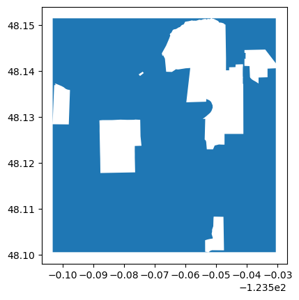

```python
# Plot the new geodataframe
outside_elwha_gdf.plot()
```

```python
# Clip data to both inside the boundary
elwha_ndvi_inside = elwha_ndvi_da.rio.clip(lower_elwha_gdf.geometry, from_disk=True)

# Print the data from inside the boundary
print(elwha_ndvi_inside)

# Clip data to both inside the boundary
elwha_ndvi_outside = elwha_ndvi_da.rio.clip(outside_elwha_gdf.geometry, from_disk=True)

# Print the data from inside the boundary
print(elwha_ndvi_outside)
```

```
<xarray.Dataset> Size: 263kB
Dimensions:      (x: 34, y: 25, date: 77)
Coordinates:
    band         int64 8B 1
  * x            (x) float64 272B -123.6 -123.6 -123.6 ... -123.5 -123.5 -123.5
  * y            (y) float64 200B 48.15 48.15 48.15 48.14 ... 48.11 48.1 48.1
  * date         (date) datetime64[ns] 616B 2008-01-14 2008-01-16 ... 2018-01-24
    spatial_ref  int64 8B 0
Data variables:
    NDVI         (date, y, x) float32 262kB nan nan nan nan ... nan nan nan nan
<xarray.Dataset> Size: 271kB
Dimensions:      (x: 35, y: 25, date: 77)
Coordinates:
    band         int64 8B 1
  * x            (x) float64 280B -123.6 -123.6 -123.6 ... -123.5 -123.5 -123.5
  * y            (y) float64 200B 48.15 48.15 48.15 48.14 ... 48.11 48.1 48.1
  * date         (date) datetime64[ns] 616B 2008-01-14 2008-01-16 ... 2018-01-24
    spatial_ref  int64 8B 0
Data variables:
    NDVI         (date, y, x) float32 270kB nan nan nan ... 0.5306 0.5306 0.5955
```

```python
# Create new dataframe for inside and compute mean annual July NDVI
july_ndvi_elwha_inside_df = (elwha_ndvi_inside
                       .groupby(elwha_ndvi_inside.date.dt.year)
                       .mean(...)
                       .NDVI.to_dataframe()
)

# Print the outside mean annual July NDVI
print('Mean NDVI inside Lower Elwha Tribe', july_ndvi_elwha_inside_df.head())

# Create new dataframe for outside and compute mean annual July NDVI
july_ndvi_elwha_outside_df = (elwha_ndvi_outside
                       .groupby(elwha_ndvi_outside.date.dt.year)
                       .mean(...)
                       .NDVI.to_dataframe()
)

# Print the outside mean annual July NDVI
print('Mean NDVI outisde Lower Elwha Tribe', july_ndvi_elwha_outside_df.head())
```

```
Mean NDVI inside Lower Elwha Tribe       band  spatial_ref      NDVI
year
2008     1            0  0.800276
2009     1            0  0.810800
2010     1            0  0.764509
2011     1            0  0.814493
2012     1            0  0.802320
Mean NDVI outisde Lower Elwha Tribe       band  spatial_ref      NDVI
year
2008     1            0  0.758740
2009     1            0  0.758149
2010     1            0  0.722739
2011     1            0  0.783135
2012     1            0  0.774991
```

```python
# Join the inside and outside GRIC dataframe
july_ndvi_elwha_df = (july_ndvi_elwha_inside_df[['NDVI']]
                .join(july_ndvi_elwha_outside_df[['NDVI']],
                      lsuffix=' Inside Lower Elwha', # Rename left column
                      rsuffix=' Outside Lower Elwha') # Rename right column
)

# Call dataframe
july_ndvi_elwha_df
```

| year | NDVI Inside Lower Elwha | NDVI Outside Lower Elwha |
| --- | --- | --- |
| 2008 | 0.800276 | 0.758740 |
| 2009 | 0.810800 | 0.758149 |
| 2010 | 0.764509 | 0.722739 |
| 2011 | 0.814493 | 0.783135 |
| 2012 | 0.802320 | 0.774991 |
| 2013 | 0.784052 | 0.756371 |
| 2014 | 0.783939 | 0.759958 |
| 2015 | 0.790558 | 0.752608 |
| 2016 | 0.777087 | 0.748260 |
| 2017 | 0.786910 | 0.763302 |
| 2018 | 0.793969 | 0.746454 |

```python
# Plot the mean NDVI iside and outside GRIC boundary
july_ndvi_elwha_df.hvplot(title='Mean July NDVI Inside and Outside Lower Elwha')
```

[output not shown]

```python
# Calculate the difference inside & outside the boundary / create column
july_ndvi_elwha_df['Difference'] = (july_ndvi_elwha_df['NDVI Inside Lower Elwha']
                                - july_ndvi_elwha_df['NDVI Outside Lower Elwha'])

# Call the new dataframe with new difference column
july_ndvi_elwha_df
```

| year | NDVI Inside Lower Elwha | NDVI Outside Lower Elwha | Difference |
| --- | --- | --- | --- |
| 2008 | 0.800276 | 0.758740 | 0.041536 |
| 2009 | 0.810800 | 0.758149 | 0.052651 |
| 2010 | 0.764509 | 0.722739 | 0.041769 |
| 2011 | 0.814493 | 0.783135 | 0.031358 |
| 2012 | 0.802320 | 0.774991 | 0.027328 |
| 2013 | 0.784052 | 0.756371 | 0.027681 |
| 2014 | 0.783939 | 0.759958 | 0.023981 |
| 2015 | 0.790558 | 0.752608 | 0.037950 |
| 2016 | 0.777087 | 0.748260 | 0.028827 |
| 2017 | 0.786910 | 0.763302 | 0.023608 |
| 2018 | 0.793969 | 0.746454 | 0.047515 |

```python
# Plot the difference in NDVI inside and ouside GRIC
july_ndvi_elwha_df.Difference.hvplot(
    title='Difference in Mean July NDVI inside & outside Lower Elwha Tribe')
```

[output not shown]

#### Tracking Vegetation Recovery to Elwha River Dam Removal: NDVI Changes Within and Outside the Lower Elwha Klallam Tribe Boundary (2008–2018)

As more dams are being removed, it is important to look at changes in ecological health over time to ensure restoration of the river’s health. This analysis of NDVI data within the Lower Elwha Klallam Tribe (LEKT) boundary revealed modest changes in vegetation over the 2008-2018 following the removal of the Elwha and Glines Canyon Dams. We do see a possible decrease in vegetation health outside the boundary which could be due to things like changes in sediment changes at the mouth of the river or urban development. While the dataset showed limited NDVI increases on tribal lands at the mouth of the river specifically, other studies and field observations indicate that vegetation recovery is occurring elsewhere in the larger watershed. This limited change near shore is consistent with other findings that saw relatively little vegetation change at the mouth of the river in the first 3 years following dam removal (Foley et al., 2017). We do see a possible increase in vegetation health towards the end of the timeframe explored, meaning that there could be more changes if looking further into the future.

Several factors likely explain the relatively small NDVI changes observed within the LEKT boundary. Vegetation recovery often occurs gradually over time, and the strongest responses are expected in areas that were previously submerged, eroded, or otherwise impacted by the dams. These locations may not be within the LEKT analyzed along the river mouth in this dataset. Additionally, natural variation, climate influences, and the substantial pre-existing vegetation cover in that area can mask short-term NDVI responses in remote sensing data.

During this analysis and project, a key takeaway is that post-dam vegetation recovery is not spatially homogenous across the watershed and could use further study following dam removals (Shafroth, Rosi, & Pess, 2024). The Elwha River is one of the most well-studied dam removal projects in the world, yet there is still a lot to be understood. The largest increases are likely to occur in regions directly influenced by restored hydrology and sediment transport rather than uniformly across the watershed or at the mouth of the river on the tribal lands. This suggests that when evaluating ecological restoration such as vegetation health with remote sensing data, it is important to carefully select areas most likely to experience change, which can provide a more complete picture of recovery. Future analysis could use different polygon data to work with the larger watershed and see changes across the entire watershed.

##### Additional Reflection

This analysis required downloading NDVI data from the NASA Earthdata portal, and a lesson learned is that data requests can take several hours to process depending on the size of the dataset. Because of this time constraint, I narrowed my analysis window to the years 2008–2018, which provided only a few years before and after the dam removals. In reality, vegetation recovery after major sediment and hydrologic changes often takes longer to appear, so a larger temporal dataset could reveal more pronounced trends. I would be interested to analyze a larger dataset in the future. My recommendation for downloading data from NASA earth data is to submit your request before you want to analyze the data so it is ready for you to begin your analysis. Just practical note and consideration in replication of this process.

References

Foley, M. M., Warrick, J. A., & Ritchie, A. C. (2017). Coastal habitat and biological community response to dam removal on the Elwha River [PDF]. U.S. Geological Survey. [https://d1wqtxts1xzle7.cloudfront.net/93105723/ecm.126820221026-1-afql5p-libre.pdf?…](https://d1wqtxts1xzle7.cloudfront.net/93105723/ecm.126820221026-1-afql5p-libre.pdf?%E2%80%A6)

Guarino, J. (2013). Tribal advocacy and the art of dam removal: The Lower Elwha Klallam Tribe’s role in restoring the Elwha River. American Indian Law Journal, 3(2), 1295–1322. Retrieved from https://digitalcommons.law.seattleu.edu/cgi/viewcontent.cgi?article=1295&context=ailj

Lee, Gabriel. “Overview: The Big Dam Era.” Energy History Online. Yale University. 2023. https://energyhistory.yale.edu/the-big-dam-era/.

Shafroth, P. B., Rosi, E. J., & Pess, G. R. (2024). Vegetation responses to large dam removal on the Elwha River, Washington, USA. Frontiers in Ecology and Evolution, 12, 1272921. https://doi.org/10.3389/fevo.2024.1272921

U.S. Environmental Protection Agency. (2021, February). Not stepping in the same river twice: Making strides in ecological restoration through dam removal. https://www.epa.gov/snep/not-stepping-same-river-twice-making-strides-ecological-restoration-through-dam-removal

U.S. National Oceanic and Atmospheric Administration, National Marine Fisheries Service. (2025, June 20). Dam removals on the Elwha River. NOAA Fisheries. https://www.fisheries.noaa.gov/west-coast/dam-removals-elwha-river